# 2IS50 – Software Development for Engineers – 2022-2023

[figure not shown]

## Lecture 7 (Extra)

Lecturer: Tom Verhoeff

### Preview of Lecture 7 (Extra)

- Course summary
- Persisting data with `pickle`
- Floating-point concerns
- Difficulty of computational problems
- Bonus

## Course Summary

- Programming: concepts, terminology
- Python: syntax, semantics, pragmatics
  - See official [Python documentation](https://docs.python.org/)
  - Python Standard Library
- Write *clean* code: **Coding Standard**
- Organize your code
  - Variables, expresssions, assignment, `if`, `for`, `while`
  - Functional decomposition, `def`
  - Data decomposition, `class`
- Avoid **code duplication** and **recomputation**
  - Introduce auxiliary variables and functions
- **Document** your code
  - type hints, docstrings, `doctest` examples
- **Test** your code
- Some algorithms, efficiency, recursion
- [**Repository with study material**](https://gitlab.tue.nl/study-material-for-2is50/study-material-2is50-2019-2020-q4/)
- Study the book **Think Python** (2e), by Allen Downey

```python
# enable mypy type checking
if 'nb_mypy' in get_ipython().magics_manager.magics.get('line'):
    %nb_mypy On
    %nb_mypy
else:
    print("nb-mypy.py not installed")
```

```
nb-mypy.py not installed
```

```python
# Preliminaries

import collections as co
from typing import Tuple, List, Set, Dict, DefaultDict, Counter
from typing import Any, Optional
from typing import Sequence, Mapping, MutableMapping, Iterable, Iterator, Callable
from typing import NewType, TypeVar
import math
import random
from pprint import pprint
import itertools as it
import doctest
```

## Persisting Data via `pickle`

- Data in variables gets lost when you close a notebook/program.
- To persist data, save it to a file or database.
- There are many formats:
  - Custom format in text file: `open`, `read`, `write`
  - Pickle (Python Object Serialization): `import pickle`
  - CSV (Comma-Separated Valued): `import csv`
  - JSON (JavaScript Object Notation): `import json`
  - ...

```python
import pickle
```

Define some data:

```python
data = ["test", 42, math.pi]
data
```

```
['test', 42, 3.141592653589793]
```

Open *binary* file for writing and **pickle** `data`:

```python
with open('test.pk', 'wb') as f:
    pickle.dump(data, f)
```

Open *binary* file for reading and **unpickle** its content:

```python
with open('test.pk', 'rb') as f:
    data2 = pickle.load(f)

data2
```

```
['test', 42, 3.141592653589793]
```

```python
data == data2
```

```
True
```

## Floating-Point Concerns

- Floating-point arithmetic *approximates* real-number arithmetic.
- They are not the same; not even *homomorphic*.

### IEEE-754 Standard for Floating-Point Arithmetic

- Open standard
- Includes positive and negative *infinite* values
- Distinguishes positive and negative zero
- Has rules to calculate with these values consistently

You can get this in Python through the **Numpy** library

### Binary notation

Floating point numbers are stored in *binary notation*

Python can print them in *hexadecimal* with `float.hex()`

- base 16, groups of 4 bits
- `...p...` stands for $\fbox{$\ldots \times 2^{ \ldots}$}$
  - shifts binary point to the right
- inverse is `float.fromhex(...)`

```python
for i in range(0, 33+1):
    print(f"{i:2} {i:6b}", float(i).hex())
```

```
 0      0 0x0.0p+0
 1      1 0x1.0000000000000p+0
 2     10 0x1.0000000000000p+1
 3     11 0x1.8000000000000p+1
 4    100 0x1.0000000000000p+2
 5    101 0x1.4000000000000p+2
 6    110 0x1.8000000000000p+2
 7    111 0x1.c000000000000p+2
 8   1000 0x1.0000000000000p+3
 9   1001 0x1.2000000000000p+3
10   1010 0x1.4000000000000p+3
11   1011 0x1.6000000000000p+3
12   1100 0x1.8000000000000p+3
13   1101 0x1.a000000000000p+3
14   1110 0x1.c000000000000p+3
```

[output cut: 19 more lines]

```python
for e in range(0, 3+1):
    x = 1 / 2 ** e
    print(f"1/{2 ** e} {x:5.3f}", float(x).hex())
```

```
1/1 1.000 0x1.0000000000000p+0
1/2 0.500 0x1.0000000000000p-1
1/4 0.250 0x1.0000000000000p-2
1/8 0.125 0x1.0000000000000p-3
```

### Smallest *positive* `float`

Making it smaller yields $0$ (underflow)

```python
min_float, e = 1.0, 0  # invariant: min_float = 2 ** e

while min_float / 2 != 0.0:
    min_float /= 2
    e -= 1

print(min_float, min_float.hex(), e)
print(min_float / 2)  # underflow
```

```
5e-324 0x0.0000000000001p-1022 -1074
0.0
```

### Largest `float`

However you try to make it larger

- either it stays the *same*
- or it becomes *infinity* (overflow)

```python
max_float, e = 1.0, 0  # invariant: max_float = 2 ** e

while max_float * 2 != math.inf:
    max_float *= 2
    if max_float + 1 - 1 == max_float:
        max_float += 1
    e += 1

print(max_float, max_float.hex(), e)
print(2 * max_float)  # overflow
```

```
1.7976931348623157e+308 0x1.fffffffffffffp+1023 1023
inf
```

Range of `float` from small to large:

- spans over 600 *orders of magnitude*
- more than enough for *science* and *engineering*

### Machine Precision

Smallest positive `float` $\varepsilon$ such that `1.0 +`$\varepsilon$`> 1.0`

- smallest relative *step size* between `float` numbers
- difference between 1.0 and next `float` > 1.0

```python
mach_prec, e = 1.0, 0  # invariant: mach_prec = 2 ** e

while 1.0 + mach_prec / 2 != 1.0:
    mach_prec /= 2
    e -= 1

print(1.0 + mach_prec, (1.0 + mach_prec).hex())
print(mach_prec, mach_prec.hex(), e)
```

```
1.0000000000000002 0x1.0000000000001p+0
2.220446049250313e-16 0x1.0000000000000p-52 -52
```

Machine precision: roughly *one nanosecond* ($10^{-9}$s) on scale of *one year* ($3\times10^{7}$s)

$$\begin{array}{l|l} \text{Factor} & \text{Name} \\ \hline 10^{-3} & \text{milli} \\ 10^{-6} & \text{micro} \\ 10^{-9} & \text{nano} \\ 10^{-12} & \text{pico} \\ 10^{-15} & \text{femto} \end{array}$$

- In Python >= 3.9: see `math.nextafter()` and `math.ulp()`
- In Numpy: see `numpy.nextafter()`

```python
import numpy as np

np.nextafter(1.0, np.inf), np.nextafter(1.0, np.inf) - 1.0
```

```
(1.0000000000000002, 2.220446049250313e-16)
```

`x: int` such that `float(x) + 1 = float(x)`

```python
max_int, e = 1.0, 0  # invariant: max_int = 2 ** e

while max_int + 1 != max_int:
    max_int *= 2
    e += 1

print(max_int, f"{max_int:e}", max_int.hex(), e)
print(max_int + 1)  # disappears after rounding
```

```
9007199254740992.0 9.007199e+15 0x1.0000000000000p+53 53
9007199254740992.0
```

```python
np.nextafter(max_int, np.inf)
```

```
9007199254740994.0
```

### Rounding

Float value `0.1` is not *exactly* $\displaystyle\frac{1}{10}$:

```python
TENTH = 0.1

f"{TENTH:.20e}"
```

```
'1.00000000000000005551e-01'
```

The representation of `0.1` in *hexadecimal* (base 16)

```python
TENTH.hex()
```

```
'0x1.999999999999ap-4'
```

In binary: $0.0001\,1001\,1001\,1001\,\cdots\,1001\,1010$

Hexadecimal representation ends in `a` ($1010$ in binary)

- it was rounded *up* (from `9`)

`0.1` converts to a binary floating-point number

- that is a tad *larger* than $\frac{1}{10}$,

When you add ten copies, the result is a tad *smaller* than $1.0$!

See if you can understand why.

Here are the ten intermediate results

- in *decimal* (approximate: conversion from internal floating-point format to decimal for printing)
- in hexadecimal (exact):

```python
r = 0.0

for _ in range(10):
    r += TENTH
    print(f"{r:.20f} {r.hex():22}")
```

```
0.10000000000000000555 0x1.999999999999ap-4
0.20000000000000001110 0x1.999999999999ap-3
0.30000000000000004441 0x1.3333333333334p-2
0.40000000000000002220 0x1.999999999999ap-2
0.50000000000000000000 0x1.0000000000000p-1
0.59999999999999997780 0x1.3333333333333p-1
0.69999999999999995559 0x1.6666666666666p-1
0.79999999999999993339 0x1.9999999999999p-1
0.89999999999999991118 0x1.cccccccccccccp-1
0.99999999999999988898 0x1.fffffffffffffp-1
```

- Floating-point operations are *not exact*
  - but involve *rounding*

### Cancelation

```python
for e in range(6+1):
    x = 10.0 ** e

    y = (x + TENTH) - x

    print(f"{x:9} {y:1.18f} {y == TENTH}")
```

```
      1.0 0.100000000000000089 False
     10.0 0.099999999999999645 False
    100.0 0.099999999999994316 False
   1000.0 0.100000000000022737 False
  10000.0 0.100000000000363798 False
 100000.0 0.100000000005820766 False
1000000.0 0.099999999976716936 False
```

```python
print(TENTH.hex())
for e in range(6+1):
    x = 10.0 ** e
    y = x + TENTH - x
    print(f"{x:>9} {x.hex():<21} {y.hex():<21} {y == TENTH}")
```

```
0x1.999999999999ap-4
      1.0 0x1.0000000000000p+0  0x1.99999999999a0p-4  False
     10.0 0x1.4000000000000p+3  0x1.9999999999980p-4  False
    100.0 0x1.9000000000000p+6  0x1.9999999999800p-4  False
   1000.0 0x1.f400000000000p+9  0x1.999999999a000p-4  False
  10000.0 0x1.3880000000000p+13 0x1.99999999a0000p-4  False
 100000.0 0x1.86a0000000000p+16 0x1.9999999a00000p-4  False
1000000.0 0x1.e848000000000p+19 0x1.9999999800000p-4  False
```

Note that value of `y` deviates more and more from $0.1$

- *Least significant bits* of `y` are zeroed by large `x`
- A.k.a. **cancelation**

### Intermezzo: Closures

```python
def poly(*coefficients: float) -> Callable[[float], float]:
    """Return polynomial with given coefficients.

    >>> poly()(1)
    0.0
    >>> poly(3)(1)  # 3 (constant polynomial)
    3.0
    >>> poly(2, 1)(1)  # 2*1 + 1 (linear)
    3.0
    >>> poly(1, 2, -1)(3)  # 3^2 + 2*3 - 1
    14.0
    """

    def f(x: float) -> float:
        """Evaluate polynomial with given coefficients.

        Uses Horner's scheme (to reduce number of multiplications)
        """
        result = 0.0

        for c in coefficients:
            result = result * x + c

        return result

    return f
```

```python
doctest.run_docstring_examples(poly, globs=globals(), name='poly')
```

Note that definition of function `f` involves `coefficients`

- these are defined *outside* `f`
- these are needed when calling the returned `f`

This returned `f` *binds* `coefficients`

- Such an `f` is known as a **closure**

### Quadratic Equation

Consider this problem:

- given $a, b, c \in \mathbb{R}$ with $a > 0$ and $b^2 > 4ac$
- finding smallest solution $x \in \mathbb{R}$ such that $a x^2 + b x + c = 0$

Mathematical solution (Quadratic Formula or $abc$-formula):

- $x = \mathcal{A}(a, b, c)$ where

$$\mathcal{A}(a, b, c) = \frac{-b - \sqrt{b^2 - 4ac}}{2a}$$

or equivalently (algebra!)

$$\mathcal{A}(a, b, c) = \frac{2c}{-b + \sqrt{b^2 - 4ac}}$$

Python solutions $\widehat{\mathcal{A}}$ and $\widehat{\mathcal{A}}'$ (`a_hat` and `a_hat_`)

```python
def a_hat(a: float, b: float, c: float) -> float:
    """Compute approximation of smallest solution x of poly(a, b, c)(x) == 0.

    Assumptions:

    * a > 0
    * b ** 2 > 4 * a * c
    """
    return (-b - math.sqrt(b ** 2 - 4 * a * c)) / (2 * a)
```

```python
coefficients = 1.0, -1e6, 1.0
quadratic = poly(*coefficients)

x = a_hat(*coefficients)
x
```

```
1.00000761449337e-06
```

```python
quadratic(x)
```

```
-7.614492369967252e-06
```

```python
def a_hat_(a: float, b: float, c: float) -> float:
    """Compute approximation of smallest solution x of poly(a, b, c)(x) == 0,
    using alternative abc-formula.

    Assumptions:

    * a > 0
    * b ** 2 > 4 * a * c
    """
    return (2 * c) / (-b + math.sqrt(b ** 2 - 4 * a * c))
```

```python
x_ = a_hat_(*coefficients)
x_
```

```
1.000000000001e-06
```

```python
quadratic(x_)
```

```
0.0
```

Explanation:

- $b < 0$
- $-b$ is large compared to $a$ and $c$
- So, $-b$ and $\sqrt{b^2 - 4ac}$ are roughly equal, with *same* sign
- Their *difference* loses significant digits due to *cancelation*
- In alternative formula, these are *added*: no cancelation

However, for *positive* $b$:

- `a_hat` is okay
- `a_hat_` suffers from cancelation

```python
coefficients_ = 1.0, 1e6, 1.0
quadratic_ = poly(*coefficients_)

x = a_hat(*coefficients_)
x_ = a_hat_(*coefficients_)

print(f"{x:16.6f}", quadratic_(x))
print(f"{x_:16.6f}", quadratic_(x_))  # useless!
```

```
  -999999.999999 -7.614492369967252e-06
  -999992.385565 -7614376.410360885
```

**Solving quadratic equations is hard!**

- Don't just use the $(a,b,c)$-formula
- Take a course on *Scientific Computing*

The following diagram does *not* commute:

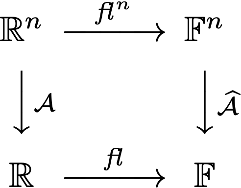

- $\mathit{fl}$ maps real number to its best floating-point approximation
- $\mathcal{A}$ is real-valued function of $n$ real numbers.
- $\widehat{\mathcal{A}}$ is floating-point version of $\mathcal{A}$ (it involves rounding)
- No guarantee that $\mathit{fl}(\mathcal{A}(x, y, \ldots)) = \widehat{\mathcal{A}}(\mathit{fl}(x), \mathit{fl}(y), \ldots)$

Also see: [Floating Point Arithmetic: Issues and Limitations](https://docs.python.org/3/tutorial/floatingpoint.html).

Example for 2-digit decimal floating-point arithmetic:

- $\mathit{fl}(1.54 + 0.34) = \mathit{fl}(1.88) = 1.9$
- $\mathit{fl}(1.54) \mathbin{\widehat{+}} \mathit{fl}(0.34) = 1.5 \mathbin{\widehat{+}} 0.34 = 1.8$

### Floating-point advice

- Don't use `float` type to solve *integer* problems.
  - Example: Is `a` divisible by `b`?
  - **BAD**: `a / b == round(a / b)`
  - **GOOD**: `a % b == 0`
  - Example: Find *integer* centered between `a` and `b`
  - **BAD**: `round((a + b) / 2)`
  - **GOOD**: `(a + b) // 2`
  - Example: Are fractions $\frac{a}{b}$ and $\frac{c}{d}$ equal?
  - **BAD**: `a / b == c / d`
  - **GOOD**: `a * d == b * c`
- Don't use `float` type for finance (fixed-point decimal problems)  
  Instead, use `Decimal`
- Don't compare `float` values for equality.  
  Exception (in some situations): `a == 0.0`  
  Instead, check *absolute* or *relative* difference.
  - **BAD**: `a == b`
  - **GOOD**: `abs(b - a) < 1e-6` (absolute difference)
  - **GOOD** `abs(b - a) / abs(a) < 1e-3` (relative diff.)
- Beware of **rounding** errors and **cancelation**.
- Prefer `math.fsum(...)` over `sum(...)` (see next example).

```python
floats = [1.0, 1e20, 1.0, -1e20] * 1000
```

`floats` is list with $4\,000$ numbers

- What is the *exact* sum?
- What do you think `sum(floats)` returns?

```python
sum(floats)
```

```
0.0
```

Better do *compensated summation*:

```python
math.fsum(floats)
```

```
2000.0
```

## Difficulty of Computational Problems

Some computational problems are harder than others

- Very easy:
  - Locate item in sorted list (*logarithmic*)
- Easy:
  - Find maximum in list (*linear*)
- Fairly easy:
  - Sort a list (better than *quadratic*: *linearithmic*)
  - List of length $N$ can be sorted in roughly $N \log_2 N$ comparisons
- Hard:
  - Finding a shortest tour visiting all cities in The Netherlands
  - *exponential*
- Impossible:
  - Decide whether a loop terminates
  - Input: Python code of the loop, and initial values of variables
  - Output: Yes/No, whether loop terminates

```python
def collatz(n: int) -> int:
    """Determine number of Collatz steps to reach 1.

    Assumption: n > 0
    """
    result = 0

    while n != 1:
        if n % 2 == 0:  # n is even
            n //= 2
        else:
            n = 3 * n + 1
        result += 1

    return result
```

```python
[collatz(n) for n in range(1, 20+1)]
```

```
[0, 1, 7, 2, 5, 8, 16, 3, 19, 6, 14, 9, 9, 17, 17, 4, 12, 20, 20, 7]
```

```python
max(((n, collatz(n)) for n in range(1, 1000+1)), key=lambda t: t[1])
```

```
(871, 178)
```

It is unknown whether `while`-loop in `collatz(n)` terminates for all `n`

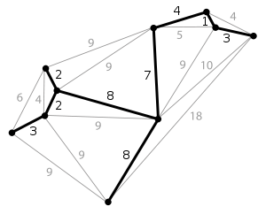

### Graph Problems and Graph Algorithms

- [Eulerian Path Problem](https://en.wikipedia.org/wiki/Eulerian_path)
  - Does there exist a path that visits *each edge once*?
- [Hamiltonian Path Problem](https://en.wikipedia.org/wiki/Hamiltonian_path_problem)
  - Does there exist a path that visits *each node once*?
- [Shortest Path Problem](https://en.wikipedia.org/wiki/Shortest_path_problem)
  - Find shortest path from source node to target node
- [Minimum Spanning Tree](https://en.wikipedia.org/wiki/Minimum_spanning_tree)
  - Find subset of edges with mimimum weight  
    that *connects all nodes*
  - This is always a 'tree'-like network
- [Traveling Salesman Problem](https://en.wikipedia.org/wiki/Travelling_salesman_problem)
  - Find path with minimum weight that visits *each node once*
- Easy:
  - Eulerian Path Problem
  - Shortest Path Problem
  - Minimum Spanning Tree
- Hard:
  - Hamiltonian Path Problem
  - Traveling Salesman Problem

### Efficient algorithms for hard problems

- *Approximation* algorithms: sacrifice *accuracy*
- *Randomized* algorithms: sacrifice *reliability*
- *Heuristic* algorithms: sacrifice *provability*

Consult experts

## Bonus: Uses of Python

- [Raspberry Pi](https://www.raspberrypi.org/)
- Mobile
  - iOS: [Pythonista](http://omz-software.com/pythonista/)
  - Android: [QPython](https://www.qpython.org/)
- [Rhino3D](https://www.rhino3d.com/): 3D design, modeling, etc.
  - [scriptable in Python](https://developer.rhino3d.com/guides/rhinopython/)
- [Blender](https://blender.org/): open-source animation engine
  - [scriptable in Python](https://docs.blender.org/api/current/info_overview.html)
  - [Blender demo](https://youtu.be/5AE5G1YUsuI)
  - [CHARGE - Blender Open Movie](https://www.youtube.com/watch?v=UXqq0ZvbOnk)

## (End of Notebook)

© 2019-2023 - **TU/e** - Eindhoven University of Technology - Tom Verhoeff